# statcast_calibrations

## Year-by-year Stadium Calibrations

I'm excited to start some baseball research using some publicly-available Statcast data, provided via the pybaseball package. Before I do anything with that data though, we need to make sure it's calibrated. Different stadiums have different dimensions and TrackMan system setups, so we shouldn't assume that data from all stadiums are created precisely equal. I'm using data going back to 2016, for 4 full seasons of data.

The easiest way to do these calibrations is with a **linear mixed-effects model** (aka **lmer**) model. These models let you vary a slope or intercept by a group. A **lmer** is perfect for this problem, since we're assuming we have 30 distinct groups (stadiums), as well as multiple years of data. So, we'll use a **lmer** to model a separate intercept for each stadium-season -- those intercepts will tell us each stadium-season's bias in each measurement.

There's a couple ways we can do this with a **lmer** model. The simplest way is probably

$$ lmer(measurement \sim 1 + (1|home\_team:year))$$

which creates 120 (30 teams x 4 seasons) totally independent intercepts. This is basically the equivalent of fitting a linear regression with 120 one-hot encoded stadium-season columns.

However, we probably want some year-to-year correlation between years within a stadium, since they're using the same system. Instead, I'll set up the model like this:

$$ lmer(measurement \sim 1 + (1 + year|home\_team)) $$

We can still extract the information for each stadium-season combination (the *random effects*), but the years are correlated.

First up, let's load in all the data and get it ready.

```
/Users/JonahKrop/Documents/Projects/Baseball
```

```python
import pandas as pd
import numpy as np
import seaborn as sns
import matplotlib.pyplot as plt
from datetime import date, datetime
```

```python
df_2016 = pd.read_csv('mlb_2016_measurements.csv')
df_2017 = pd.read_csv('mlb_2017_measurements.csv')
df_2018 = pd.read_csv('mlb_2018_measurements.csv')
df_2019 = pd.read_csv('mlb_2019_measurements.csv')

# combine each year's data into 1 df
df = pd.concat([df_2016, df_2017, df_2018, df_2019], axis=0)

# add unique ID for each pitch in dataset
df.insert(0, 'pitch_id', list(range(len(df))))

# pull year out of date
df.insert(2, 'year', df.game_date.apply(
    lambda x: datetime.strptime(x, '%Y-%m-%d').year))

# filter out misreads assigned a number, for some reason
df = df[df['pitch_type'].str.len()<=2]

# grab columns to calibrate
feats = list(df.columns[17:-2])
```

## Setting up Data

The data comes with stuff like pitcher and batter ID's, the hit type, what inning it is, etc. We're only calibrating numeric data, which include:

- pitch speed
- pitch release point (x, y, z)
- pitch movement, horizontal and vertical
- pitch initial velocity (x, y, z)
- pitch acceleration (x, y, z)
- pitch spin rate
- batted ball speed
- batted ball launch angle
- batted ball distance

To make this a little cleaner, I'm going to filter our data down to *four-seam fastballs* only. That should make it easier to pull out the effects of each stadium on our measurements instead of confusing the model with pitches of different speed and movement profiles. We could add another group for `pitch_type` to the model, but I think that would unecessarily complicate it. After all, the stadiums aren't selectively choosing to mess up four-seams and not sliders.

Four-seam fastballs (designated `FF`) are easily the most common pitch, which makes them an easy choice.

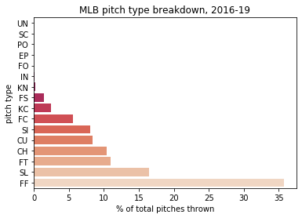

```
Total FF dataset size: 1028127 points
```

## Model Setup

At this point, I'm ready to throw everything into a model. I don't need 1M+ data points for this so I'll randomly sample some smaller amount. Let's break out **R** and loop through each feature in a lmer model. First, I'll do `release_speed` by itself as an example.

```python
%%R -i ff
library(lme4)

dat <- ff[complete.cases(ff[, 'release_speed']),] # drop any nan's
dat_s <- dat[sample(nrow(dat), 20000),] # use small sample for ex.

model <- lmer("release_speed ~ 1 + (1 + factor(year)|home_team)", data=dat_s)

rnf <- as.data.frame(ranef(model)) # want random effects (group-related effects)

print(rnf[sample(nrow(rnf), 10),]) # sample 10 random rows
```

```
R[write to console]: Loading required package: Matrix
```

```
       grpvar             term grp     condval    condsd
99  home_team factor(year)2019 CWS  0.03027862 0.2187904
100 home_team factor(year)2019 DET -0.22872708 0.2105202
86  home_team factor(year)2018 STL -0.51865478 0.2459780
106 home_team factor(year)2019 MIL  0.20776771 0.2215125
7   home_team      (Intercept) CLE -0.19591814 0.1579174
6   home_team      (Intercept) CIN  0.20738349 0.1589340
54  home_team factor(year)2017 SEA  0.41784603 0.2148491
14  home_team      (Intercept) LAD  0.22149546 0.1565748
77  home_team factor(year)2018 MIN  0.24593685 0.2438196
85  home_team factor(year)2018  SF  0.06732585 0.2519992
```

Let's look real quick at these random effects in the `condval` column. They're telling us the bias each stadium has in a given year. For example, the Chicago White Sox were pretty much right on the money in 2019 compared to other stadiums. On the other hand, the St. Louis stadium was around 0.5 mph cold in 2018. These are pretty small adjustments overall, which is good.

Time to finish this off by looping through all the measurements.

```python
%%R -i ff,feats -o adj
library(lme4)
library(plyr)

adj <- unique(ff[, c('home_team', 'year')]) # set up master dataframe with all team-year combos
row.names(adj) <- NULL # reset index

for(f in feats){

    cat("Currently doing", f)

    dat <- ff[complete.cases(ff[, c(f)]),] # drop any nan's
    dat_s <- dat[sample(nrow(dat), 175000),] # sample 175k data points

    eqn <- paste(f, " ~ 1 + (1 + factor(year)|home_team)", sep="") # set eqn
    model <- lmer(eqn, data=dat_s)

    rnf <- as.data.frame(ranef(model)) # extract random/group effects

    # replace 'term' column entries with year
    rnf$term <- as.character(rnf$term)
    rnf$term[rnf$term == "(Intercept)"] <- "2016"
    rnf$term[rnf$term == "factor(year)2017"] <- "2017"
    rnf$term[rnf$term == "factor(year)2018"] <- "2018"
    rnf$term[rnf$term == "factor(year)2019"] <- "2019"

    # select and rename columns
    rnf <- rnf[, c('term', 'grp', 'condval')]
    colnames(rnf) <- c('year', 'home_team', f)

    adj <- merge(adj, rnf, by=c('home_team', 'year')) # merge in to master df

}

print('Done!')
```

```
Done!
```

[output not shown]

## Results

We're done! Above is a sampling of the adjustments. What each entry tells us is the size of the bias for each measurement for each stadium and season. Using the first entry as an example, Baltimore's stadium in 2016 measured release speed around 0.6 mph low. So, we'll add 0.665 mph to all the pitches thrown in Baltimore in 2016.

I'll just join these results in with our original set of data and we'll be all set.

```python
# add suffix so column names aren't the same (oops)
adj = adj.add_suffix('_adj')
df_cols = list(df.columns)

df_adj = pd.merge(df, adj, how='inner',
                  left_on=['year', 'home_team'],
                  right_on=['year_adj', 'home_team_adj'])

# apply adjustment to each column
for f in feats:
    f_adj = f + '_adj'
    df_adj[f] = df_adj[f] - df_adj[f_adj]

# finalize df
df_save = df_adj[df_cols]
df_save[feats] = df_save[feats].round(3)  # no need for lots of decimal places

print('Success!')
```

```
Success!
```